# Davis and Othmer & Stevens random walks

Author

Markus Owen

Published

February 12, 2026, 13:34:32

Modified

February 12, 2026, 13:34:24

# 1 Introduction

From Aggregation, Blowup, and Collapse: The ABC’s of Taxis in Reinforced Random Walks, Hans G. Othmer and Angela Stevens https://doi.org/10.1137/S0036139995288976.

# 2 Implementing the random walk model from Davis 1990

The model is for a single cell (e.g. bacterium) which jumps left or right with probability depending on the weight of the edge between lattice sites. Each time the cell makes a jump along an edge, it deposits a signal on that edge. If there are $N$ sites, there should be $N-1$ edges.

```python
import numpy as np
import matplotlib.pyplot as plt
from scipy import stats
```

The first (zeroth) entry in $w$ is the first edge between sites $0$ and $1$ (using Python zero indexing). So a move to the left from $i$ to $i-1$ should increment edge $i-1$, a move to the right from $i$ to $i+1$ should increment edge $i$.

Initially there is a weight on each interval $(i, i+ 1), i \in \mathbb{Z}$, which is equal to 1.

If at time $n$ an interval has been crossed by the particle exactly $k$ times, its weight will be $w=1+\sum_{j=1}^k a_j$, where $a_j \ge 0$, $j = 1,\dots,k$.

If $(X_0, X_1, \dots, X_n) = (i_0, i_1, \dots, i_n)$ are given, then the probability that $X_{n+1}$ is $i_{n−1}$ (move to left) or $i_{n + 1}$ (move to right) is proportional to the weights at time $n$ of the intervals $(i_{n−1}, i_n)$ and $(i_n, i_{n + 1})$.

$$p_l = \frac{w_{n-1}}{w_{n-1}+w_{n}}$$
where we take the convention that $w_i$ is the weight associated with the interval $(i_{n}, i_{n+1})$

```python
def sim_walk(x0,w,a,N,nt):
    n_moves = np.zeros(N-1,dtype=np.int64) # number of moves across each edge
    x = []
    x.append(x0)
    p = []
    n_left = 0
    for i in np.arange(nt):
        r = rng.uniform()
        p_left = w[x[-1]-1]/(w[x[-1]-1]+w[x[-1]])
        p.append(p_left)
        if r<p_left:
            # move left
            x.append(x[-1]-1)
            if (x[-1] == 0 | x[-1] == N-1):
                print(f'Reached the boundary, x={x[-1]}')
            n_moves[x[-1]-1] += 1
            w[x[-1]-1] += a[n_moves[x[-1]-1]]
            n_left += 1
        else:
            # move right
            x.append(x[-1]+1)
            n_moves[x[-1]] += 1
            w[x[-1]] += a[n_moves[x[-1]]]
    return x,n_moves,w,p,n_left
```

## 2.1 First test with zero weight increments (simple diffusion)

The vector of weights $\mathbf{a}$ may need to have as many as $n_t$ elements in case the same edge is crossed repeatedly.

Here we set $\mathbf{a}=\mathbf{0}$ so the walk is unbiased, $p_l=p_r=0.5$ always.

```python
N = 201 # number of lattice sites
w = np.ones(N-1) # initial weight at each edge
nt = 20 # number of time steps
x0 = int((N-1)/2)
rng = np.random.default_rng(12345)
a = 0.0*np.ones(nt) # weight to add for each move
```

```python
x,n_moves,w,p,n_left = sim_walk(x0,w,a,N,nt)
```

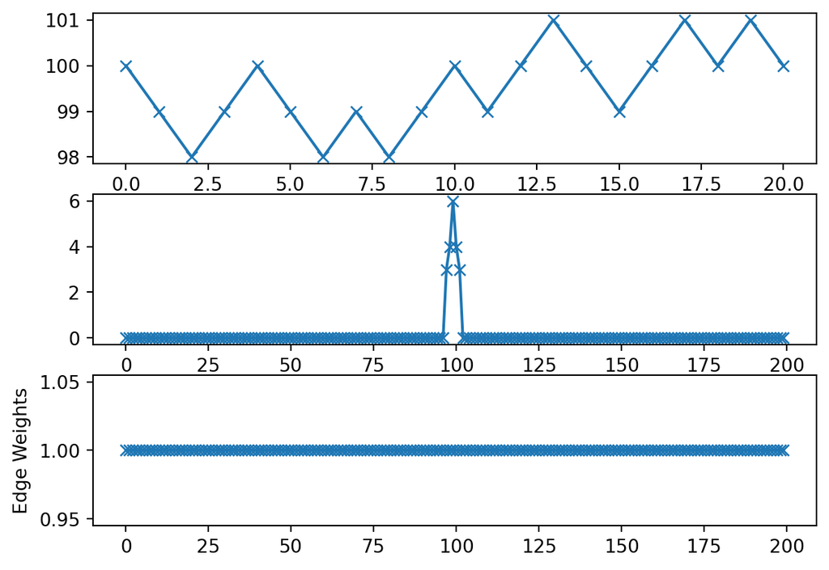

```python
fig, ax = plt.subplots(3,1)
ax[0].plot(x,'-x')
ax[1].plot(n_moves,'-x')
ax[2].plot(w,'-x')
ax[2].set_ylabel('Edge Weights')
plt.show()
```

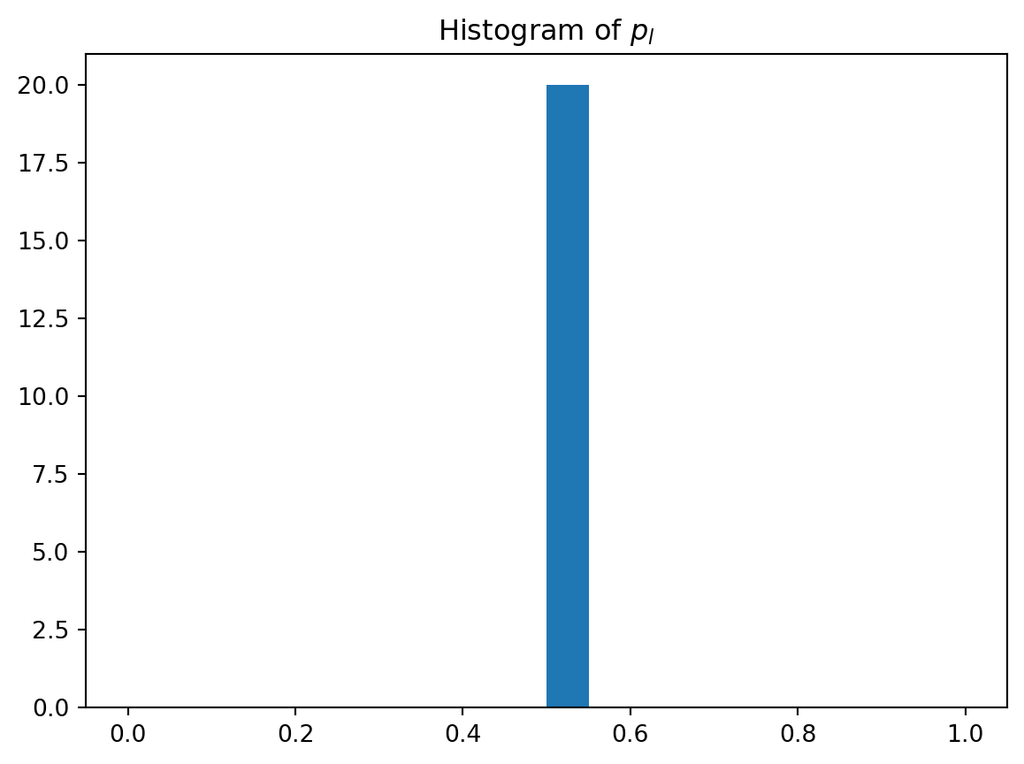

```python
plt.hist(p,bins=20,density=True)
plt.title('Histogram of $p_{l}$')
plt.show()
```

### 2.1.1 Run for longer

```python
N = 201 # number of lattice sites
w = np.ones(N-1) # initial weight at each edge
nt = 10000 # number of time steps
x0 = int((N-1)/2)
rng = np.random.default_rng(12345)
a = 0.0*np.ones(nt) # weight to add for each move
```

```python
x,n_moves,w,p,n_left = sim_walk(x0,w,a,N,nt)
```

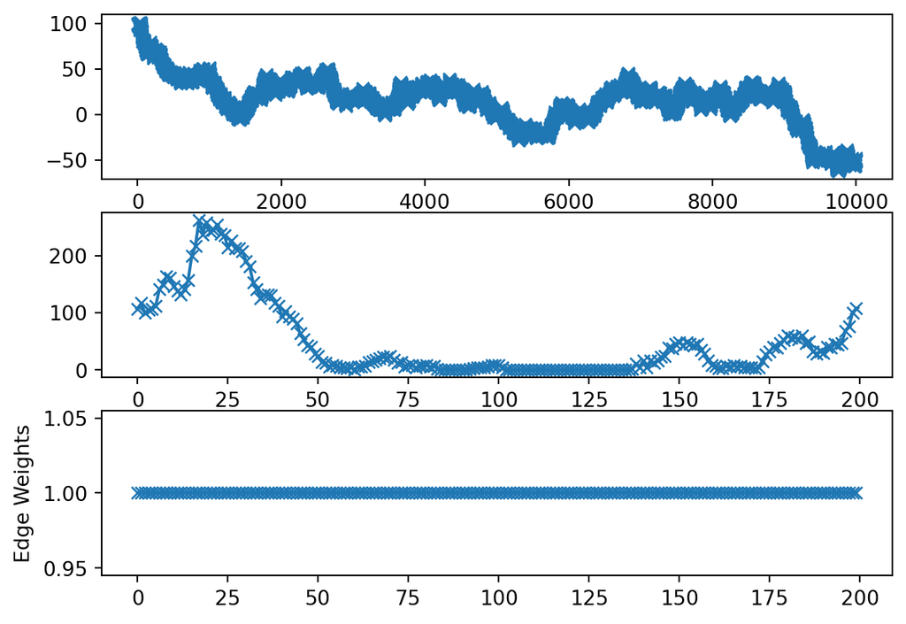

```python
fig, ax = plt.subplots(3,1)
ax[0].plot(x,'-x')
ax[1].plot(n_moves,'-x')
ax[2].plot(w,'-x')
ax[2].set_ylabel('Edge Weights')
plt.show()
```

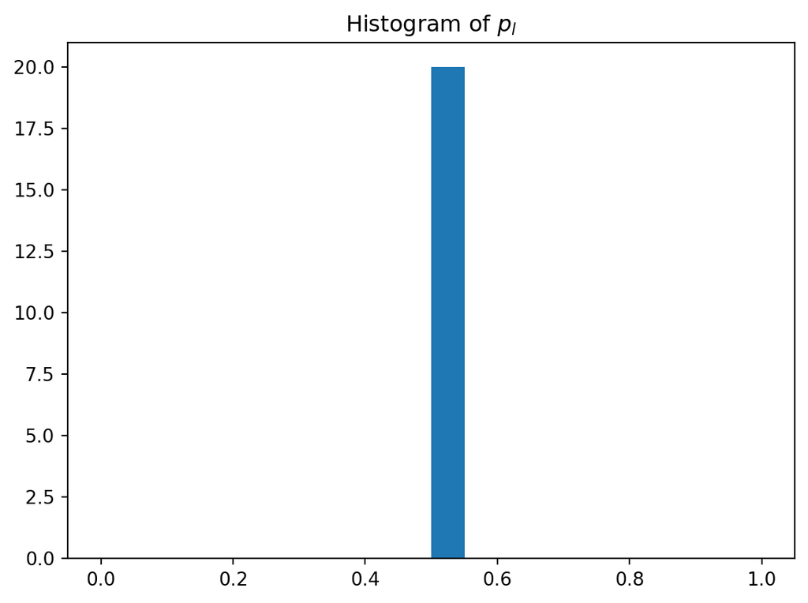

```python
plt.hist(p,bins=20,density=True)
plt.title('Histogram of $p_{l}$')
plt.show()
```

## 2.2 Run many times and store final positions

```python
N = 201 # number of lattice sites
w0 = np.ones(N-1) # initial weight at each edge
nt = 400 # number of time steps
x0 = int((N-1)/2)
rng = np.random.default_rng(12345)
a = 0.0*np.ones(nt) # weight to add for each move
```

```python
x_store = []
n_lefts = []
for i in np.arange(10000):
    w = w0
    x,n_moves,w,p,n_left = sim_walk(x0,w,a,N,nt)
    x_store.append(x[-1])
    n_lefts.append(n_left)
```

The end position should be normally distributed about the starting point $x=x_0$, and the number of moves left should be normally distributed about a mean of $n_t/2$ (with the unbiased walk, half the steps should be left, on average):

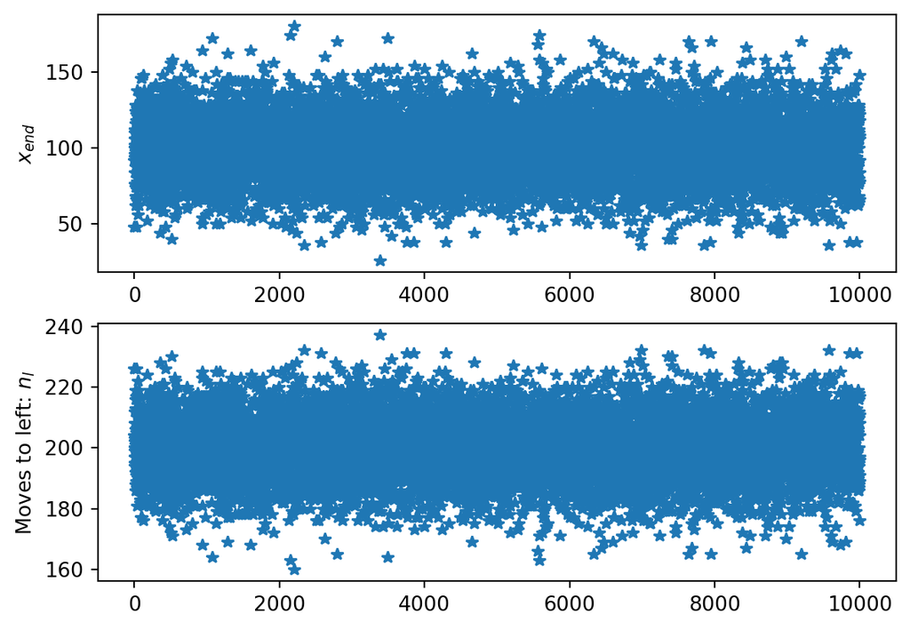

```python
fig, ax = plt.subplots(2,1)
ax[0].plot(x_store,'*')
ax[0].set_ylabel('$x_{end}$')
ax[1].plot(n_lefts,'*')
ax[1].set_ylabel('Moves to left: $n_{l}$')
plt.show()
```

Histogram of final position with test of normality:

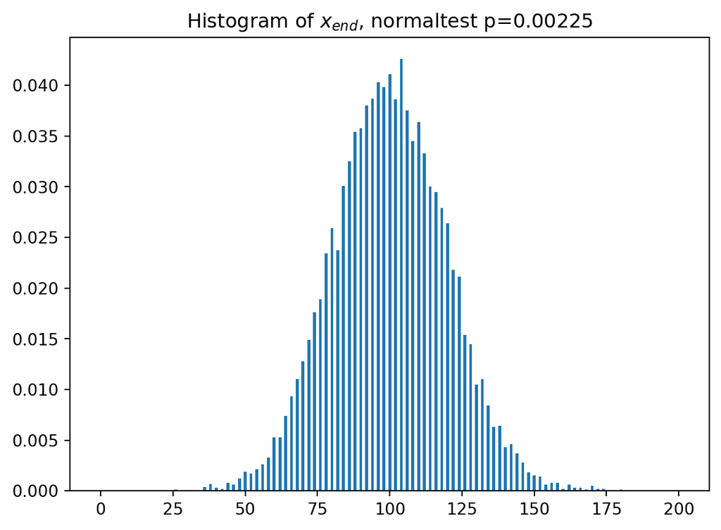

```python
res = stats.normaltest(x_store)
plt.hist(x_store,bins=np.linspace(-0.5,N-0.5,N+1),density=True)
plt.title(f'Histogram of $x_{{end}}$, normaltest p={float('%.3g' % res.pvalue)}')
plt.show()
```

## 2.3 Second test with constant weight increments

```python
N = 101 # number of lattice sites
w = np.ones(N-1) # initial weight at each edge
nt = 10000 # number of time steps
x0 = int((N-1)/2)
rng = np.random.default_rng(12345)
a = 0.2*np.ones(nt) # weight to add for each move
```

```python
x,n_moves,w,p,n_left = sim_walk(x0,w,a,N,nt)
```

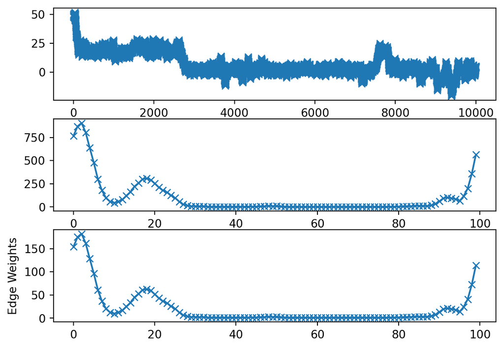

```python
fig, ax = plt.subplots(3,1)
ax[0].plot(x,'-x')
ax[1].plot(n_moves,'-x')
ax[2].plot(w,'-x')
ax[2].set_ylabel('Edge Weights')
plt.show()
```

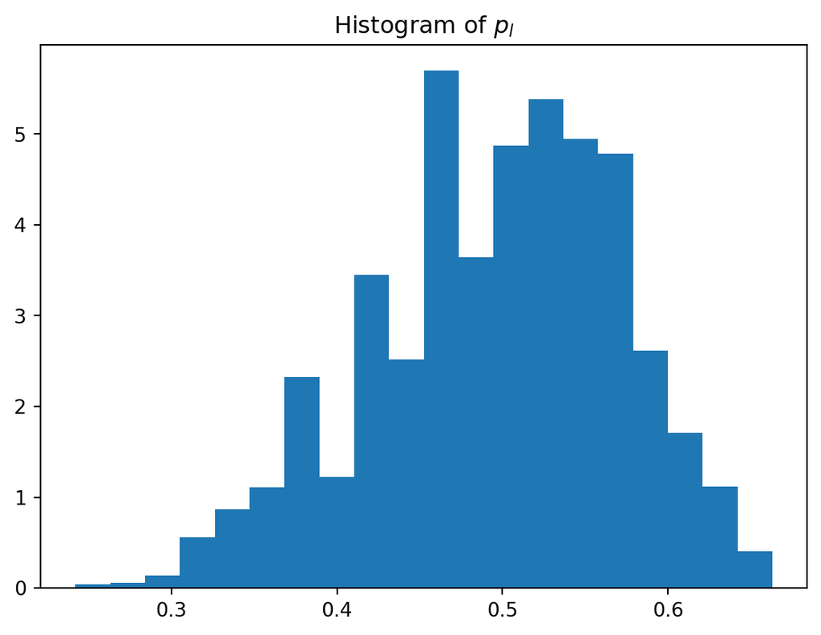

```python
plt.hist(p,bins=20,density=True)
plt.title('Histogram of $p_{l}$')
plt.show()
```

## 2.4 Same with faster (quadratic) weight growth

```python
N = 101 # number of lattice sites
w = np.ones(N-1) # initial weight at each edge
nt = 1000 # number of time steps
x0 = int((N-1)/2)
rng = np.random.default_rng(12345)
a = np.arange(nt)**2+1
```

```python
x,n_moves,w,p,n_left = sim_walk(x0,w,a,N,nt)
```

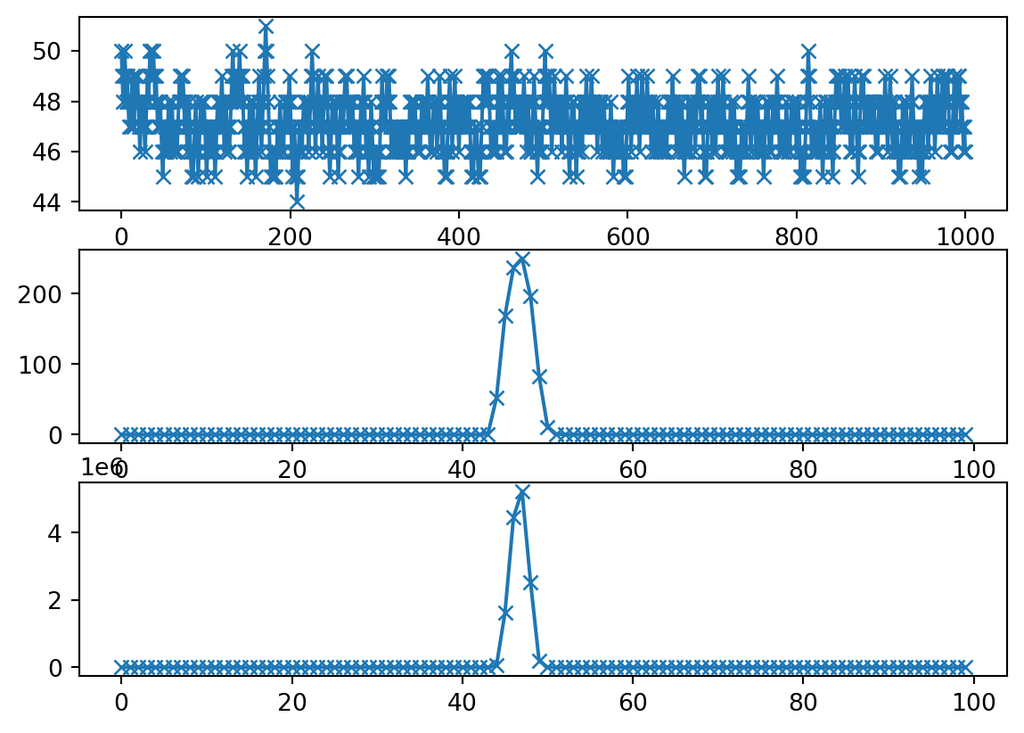

```python
fig, ax = plt.subplots(3,1)
ax[0].plot(x,'-x')
ax[1].plot(n_moves,'-x')
ax[2].plot(w,'-x')
plt.show()
```

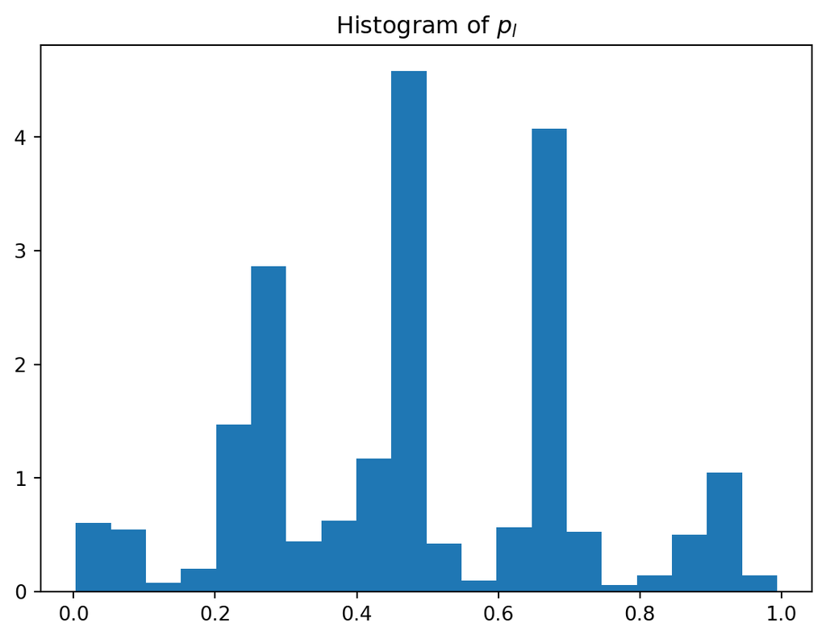

```python
plt.hist(p,bins=20,density=True)
plt.title('Histogram of $p_{l}$')
plt.show()
```

To reach a limit where the state switches constantly between $n$ and $n+1$ the weights must reach a state where there are two adjacent points with very large values and either side of that the values are negligible. Something like $(0,\cdots,0,\epsilon,M,M,\epsilon,0,\cdots,0)$. This would mean the probability of a left (right) move from the first (second) location with $w=M$ is $p_{l(r)}=\epsilon/(\epsilon+M) \approx 0$ and a right (left) move is $p_{r(l)}=M/(\epsilon+M) \approx 1$.

```python
N = 101 # number of lattice sites
w = np.ones(N-1) # initial weight at each edge
nt = 100 # number of time steps
x0 = int((N-1)/2)
rng = np.random.default_rng(12345)
a = np.arange(nt)**3+1
```

```python
x,n_moves,w,p,n_left = sim_walk(x0,w,a,N,nt)
```

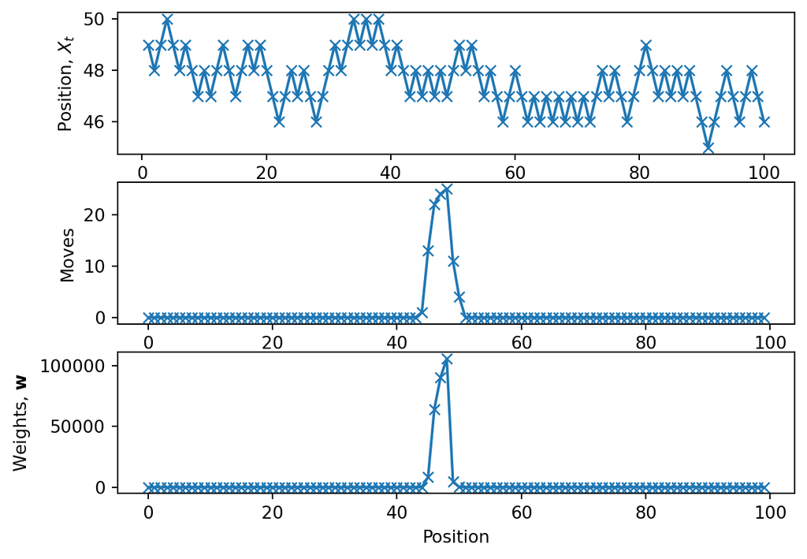

```python
fig, ax = plt.subplots(3,1)
ax[0].plot(np.arange(nt-100,nt)+1,x[-100:],'-x')
ax[0].set_xlabel('Time step')
ax[0].set_ylabel(r'Position, $X_t$')
ax[1].plot(n_moves,'-x')
ax[1].set_xlabel('Position')
ax[1].set_ylabel('Moves')
ax[2].plot(w,'-x')
ax[2].set_xlabel('Position')
ax[2].set_ylabel(r'Weights, $\mathbf{w}$')
plt.show()
```

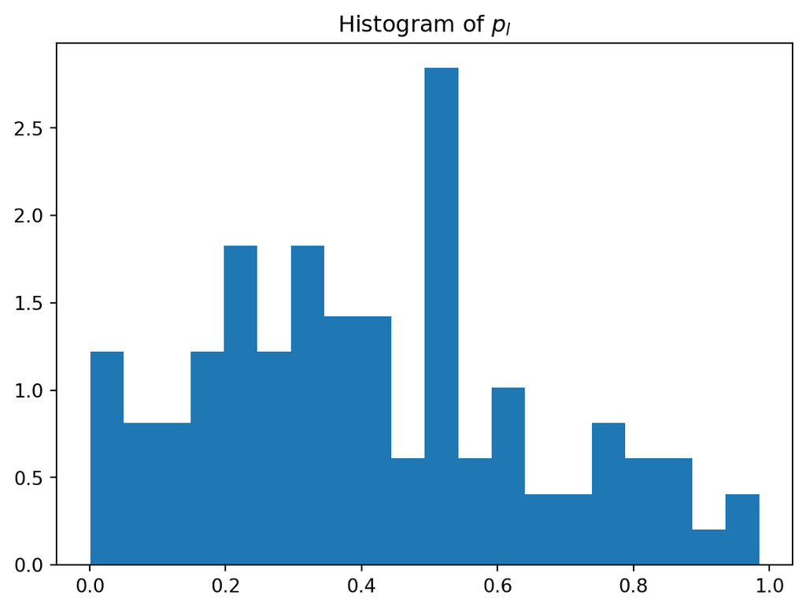

```python
plt.hist(p,bins=20,density=True)
plt.title('Histogram of $p_{l}$')
plt.show()
```

# 3 Implementing the modified random walk model due to Othmer and Stevens

This random walk is similar but the weights are placed at lattice sites instead of on edges between sites.

NOT IMPLEMENTED YET.